# DoD Military Community and Family Policy Military OneSource eNewsletter: Google Analytics Results

Paul Testa and Jake Bowers

August 29, 2016

# Setup

This chunk records the series of steps we took to clean and collapse the Google Analytics data after converting it to csv via excel.

```bash
## Assuming the bash or zsh shell. This is not R code
cp SBST-Batch-SendTracking-GAStats-15Aug2016.csv orig.csv
sed -i "" "s/\*no //g" SBST-Batch-SendTracking-GAStats-15Aug2016.csv
## By Hand: Added a header
sed -i "" 's/\/15,.*$/\/15,/' SBST-Batch-SendTracking-GAStats-15Aug2016.csv
sed -i "" 's/\/16,.*$/\/16,/' SBST-Batch-SendTracking-GAStats-15Aug2016.csv
gsed -i.bak '/^[0-9]/! s/^/,/' SBST-Batch-SendTracking-GAStats-15Aug2016.csv ## add extra column, use gnu-sed from brew install gnu-sed
gsed -i.bak 's/reported/\/ email/g' SBST-Batch-SendTracking-GAStats-15Aug2016.csv
```

The version of `SBST-Batch-SendTracking-GAStats-15Aug2016.csv` on Google Drive was cleaned as above. To execute this file, you’ll need to download it.

```r
gadat <- read.csv("data/SBST-Batch-SendTracking-GAStats-15Aug2016.csv", as.is = TRUE, header = TRUE)
gadat$Source...Medium[gadat$Source...Medium == ""] <- NA
table(gadat$Source...Medium)
```

```
newsletter_a / email newsletter_b / email newsletter_c / email newsletter_d / email
                 103                  103                  103                  103
newsletter_e / email newsletter_f / email
                 103                  103
```

Google Analytics recorded data for each newsletter treatment for 103 days from the end of Nov 2015 to early March 2016.

```r
range(mdy(gadat$X[gadat$X != ""]))
```

```
[1] "2015-11-24" "2016-03-05"
```

This next just reorganizes the data for easier analysis.

```r
tabdat <- gadat %>% group_by(Source...Medium) %>% summarise(sum(New.Users, na.rm = TRUE))
names(tabdat) <- c("treatment", "newusers")
tabdat <- tabdat[-7, ]
wrkdat <- read.csv("data/wrkdat.csv", as.is = TRUE)
assigndat <- wrkdat %>% group_by(treatment) %>% summarize(sent = n())

dat <- cbind(assigndat, newusers = tabdat$newusers)
stopifnot(tabdat[tabdat$treatment == "newsletter_a / email", "newusers"] == dat[dat$treatment == "A",
    "newusers"])

dat$success <- dat$newusers
dat$failures <- dat$sent - dat$newusers

mat <- as.matrix(dat[, c("success", "failures")])
rownames(mat) <- as.character(dat$treatment)
```

Expand these tables to make analyses easier with existing software:

```r
bigdat <- melt(apply(mat, 1, function(x) {
    c(rep(1, x[1]), rep(0, x[2]))
}))
names(bigdat) <- c("newvisit", "treatment")
bigdat$newvisitF <- factor(bigdat$newvisit, levels = c(1, 0))
bigdat$treatmentF <- factor(bigdat$treatment)
tab2 <- with(bigdat, table(treatment, newvisitF))
proptab2 <- prop.table(tab2, margin = 1)
```

The emails generated 8697 visits to the newsletter website.

```r
bigdat$active <- ifelse(bigdat$treatment %in% c("F", "D", "B"), 1, 0)
prop.table(with(bigdat, table(active, newvisit)), margin = 1)
```

```
      newvisit
active       0       1
     0 0.98388 0.01612
     1 0.98076 0.01924
```

```r
bigdat$short <- ifelse(bigdat$treatment %in% c("F", "E"), 1, 0)
prop.table(with(bigdat, table(short, newvisit)), margin = 1)
```

```
     newvisit
short       0       1
    0 0.98394 0.01606
    1 0.97909 0.02091
```

# Test for any difference across treatments

Now, assess the hypotheses of no difference among treatments (comparing the approximate chisq test that does not rely on large sample assumptions to the one that relies on large sample assumptions). We have a lot of evidence that the different treatments had different effects.

```r
prop.test(x = tab2[, 1], n = rowSums(tab2))
```

```
    6-sample test for equality of proportions without continuity correction

data:  tab2[, 1] out of rowSums(tab2)
X-squared = 250, df = 5, p-value <2e-16
alternative hypothesis: two.sided
sample estimates:
 prop 1  prop 2  prop 3  prop 4  prop 5  prop 6
0.01566 0.01832 0.01432 0.01596 0.01837 0.02346
```

```r
chisq_test(newvisitF ~ treatmentF, data = bigdat)  ## or chisq_test(tab2)
```

```
    Asymptotic Pearson Chi-Squared Test

data:  newvisitF by treatmentF (A, B, C, D, E, F)
chi-squared = 250, df = 5, p-value <2e-16
```

```r
## This next just checks to see if our reliance on the central limit theorem is warranted in a
## situation with such rare outcomes.
chisq_test(newvisitF ~ treatmentF, data = bigdat, distribution = approximate(B = 1000))
```

```
    Approximative Pearson Chi-Squared Test

data:  newvisitF by treatmentF (A, B, C, D, E, F)
chi-squared = 250, p-value <2e-16
```

# Which treatment was most effective?

Treatment F (the “Active”) treatment was clearly the most effective at increasing the number of new devices or web browsers loading the first page of the newsletter site with roughly 2.3% of those sent this treatment accessing the website compared to, say, about 1.4% for treatment C. Note that this is only the same as increasing the number of people responding to the email if each person only reached the web page once. More likely these treatments motivated people to both click on the link but also to try to use different devices to reach the site — perhaps to show it to others, or if it didn’t load well on their preferred device or over the network they were using when they read the email.

```r
thelm <- lm(newvisit ~ treatmentF, data = bigdat)
c(coef(thelm)[1], coef(thelm)[1] + coef(thelm)[2:6])
```

```
(Intercept) treatmentFB treatmentFC treatmentFD treatmentFE treatmentFF
    0.01566     0.01832     0.01432     0.01596     0.01837     0.02346
```

```r
coeftest(thelm, vcov = vcovHC(thelm, type = "HC2"))
```

```
t test of coefficients:

             Estimate Std. Error t value Pr(>|t|)
(Intercept)  0.015662   0.000434   36.12  < 2e-16 ***
treatmentFB  0.002659   0.000638    4.17 0.000031 ***
treatmentFC -0.001342   0.000600   -2.24    0.025 *
treatmentFD  0.000293   0.000616    0.48    0.635
treatmentFE  0.002708   0.000639    4.24 0.000022 ***
treatmentFF  0.007795   0.000684   11.40  < 2e-16 ***
---
Signif. codes:  0 '***' 0.001 '**' 0.01 '*' 0.05 '.' 0.1 ' ' 1
```

```r
allcomps <- glht(thelm, linfct = mcp(treatmentF = "Tukey"))
sumallcomps <- summary(allcomps)
allcompsci <- confint(allcomps)  ## adjusted for multiple comparisons
```

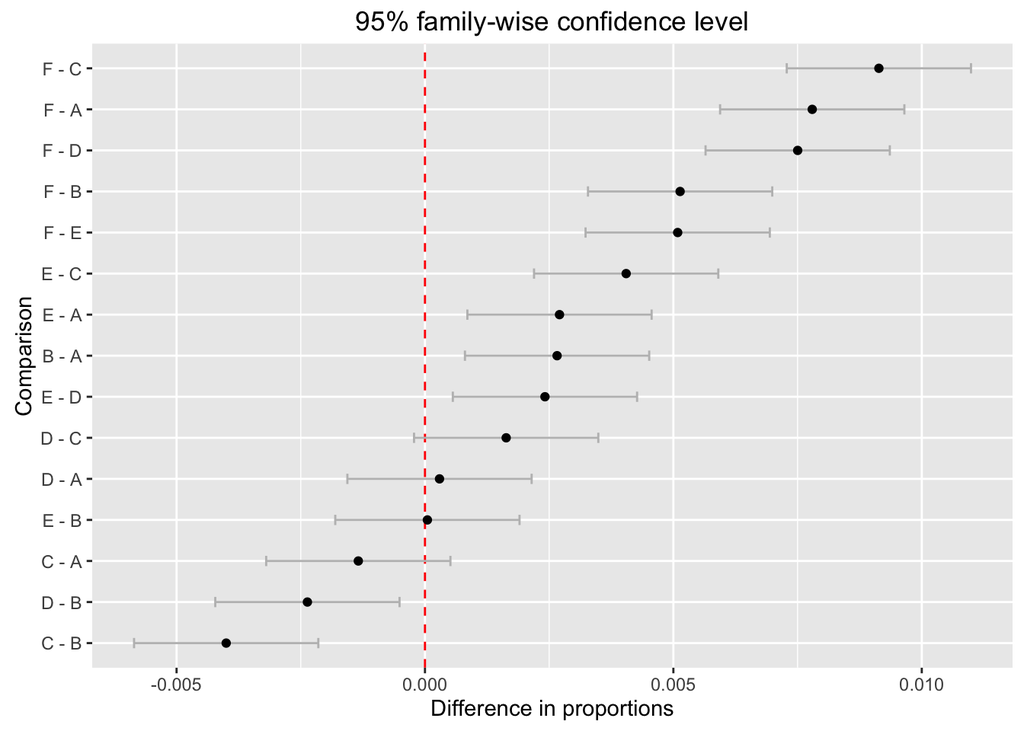

```r
# Get estimates and intervals
tukey <- data.frame(allcompsci$confint)
## plot(TukeyHSD(a1))
tukey$Comparison <- factor(rownames(tukey), levels = rev(rownames(tukey)))
tukey$Comparison <- factor(tukey$Comparison, levels = tukey$Comparison[order(tukey$Estimate)])

p.tukey <- ggplot(tukey, aes(y = Comparison, x = Estimate)) + geom_vline(xintercept = 0, linetype = 2,
    col = "red") + geom_errorbarh(aes(xmin = lwr, xmax = upr), height = 0.25, col = "grey") + geom_point() +
    labs(x = "Difference in proportions", title = "95% family-wise confidence level")
p.tukey
```

The next figure shows the estimated proportions.

```r
lm2 <- lm(newvisit ~ treatmentF - 1, data = bigdat)
source("confintHC.R")  ## our own CI maker with HC SEs
theCIs <- confint(lm2, vcov = vcovHC(lm2, type = "HC2"))
```

```r
theCIs <- as.data.frame(theCIs)
theCIs$Treatment <- c("Opt-in; List (A)", "Active; List (B)", "Opt-in; Quiz (C)", "Active; Quiz (D)",
    "Opt-in (E)", "Active (F)")
theCIs$pbar <- coef(lm2)
theCIs$Treatment <- factor(theCIs$Treatment, levels = theCIs$Treatment[order(theCIs$pbar)])
names(theCIs)[1:2] <- c("ll", "ul")
```

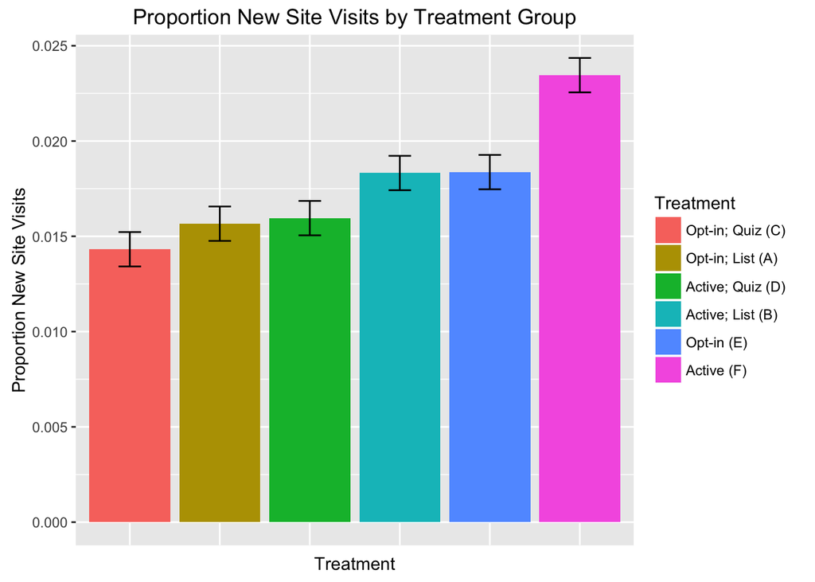

```r
# Plot with ggplot2
dodge <- position_dodge(width = 0.9)
p.props <- ggplot(theCIs, aes(Treatment, pbar, fill = Treatment)) + geom_bar(stat = "identity", position = dodge) +
    geom_errorbar(aes(ymin = ll, ymax = ul), position = dodge, width = 0.25) + labs(list(y = "Proportion New Site Visits",
    title = "Proportion New Site Visits by Treatment Group")) + theme(axis.text.x = element_blank(),
    axis.ticks.x = element_blank())
p.props
```